# npda-extended-analysis

[figure not shown]

[figure not shown]

[figure not shown]

[figure not shown]

# National Paediatric Diabetes Audit (NPDA) Report on Care and Outcomes 2023/24

### Appendix 1 - Full audit analysis

# 1 Characteristics, prevalence, and incidence

## 1.1 Audit cohort

A total of 35,122 children and young people with diabetes were included in the 2023/24 audit. 172 of the 172 Paediatric Diabetes Units (PDUs) in England and Wales participated.

Table 1 shows the breakdown of this cohort by age group and type of diabetes.

Table 1: Number of children and young people with diabetes by age-group and type of diabetes in 2023/24

|  | 0-4 years | 5-9 years | 10-14 years | 15-19 years** | 20-24 years** | Total | % of cohort |
| --- | --- | --- | --- | --- | --- | --- | --- |
| Type 1 diabetes | 1842 | 6544 | 13699 | 10701 | 23 | 32809 | 93.4% |
| Type 2 diabetes | 5 | 31 | 477 | 846* |  | 1359 | 3.9% |
| Cystic fibrosis-related diabetes |  | 20* | 103 | 73* |  | 196 | 0.6% |
| Monogenic forms of diabetes | 9 | 23 | 82 | 75* |  | 189 | 0.5% |
| Other specified diabetes mellitus | 40 | 79 | 186 | 155 | 0 | 460 | 1.3% |
| Not specified diabetes mellitus |  | 28* | 48 | 33 | 0 | 109 | 0.3% |

* Results merged to mask number <4  
** The NPDA recognises that transition to adult diabetes services usually starts in a patient’s late teenage years. The numbers presented in these columns represents the number still receiving care from a PDU and do not represent the total number of young people with diabetes in these age groups in England and Wales. Refer to the Adolescent and Young Adult (AYA) reports for numbers 16-25 years old.[^1]

## 1.2 Characteristics of children and young people with Type 1 diabetes

### 1.2.1 Age and sex

Figure 1 shows the number of children and young people with Type 1 diabetes by sex and age in whole years at the beginning of the audit period.

The distribution by age and sex is consistent with previous years. The number of children increases up to 14-15 years, when many young people start to transition to adult services. Boys account for 52.6% of the sample.

**Figure 1:** Total number of children and young people with Type 1 diabetes by age and sex, 2022/23 and 2023/24

[interactive chart not shown]

### 1.2.2 National distribution

Table 2 shows the number of children and young people with Type 1 diabetes, by age group, included in the 2023/24 audit, both overall and by country. Country allocation was based on the last PDU attended within the audit year.

**Table 2:** Number of children and young people with Type 1 diabetes by country and age group, 2023/24

| Country | 0-4 years | 5-9 years | 10-14 years | 15-19 years | 20-24 years | Total | % of cohort |
| --- | --- | --- | --- | --- | --- | --- | --- |
| England and Wales | 1842 | 6544 | 13699 | 10701 | 23 | 32809 | 100% |
| England | 1738 | 6212 | 12969 | 10248 | 23 | 31190 | 95.1% |
| Wales | 104 | 332 | 730 | 453 | 0 | 1619 | 4.9% |

### 1.2.3 Ethnicity

The ethnic breakdown of children and young people with Type 1 diabetes reported to the 2023/24 audit is shown in Table 3. Percentages are also shown excluding ‘not stated’ and ‘unknown’ categories to allow for comparison with the 2021 census data[^2]. The distribution of Type 1 diabetes by ethnic status is similar to the background population.

**Table 3:** Ethnic groups of children and young people with Type 1 diabetes in England and Wales, 2023/24

| Ethnicity | No. of children and young people with T1 diabetes | % of cohort | % of total with stated ethnicity | % of total population* |
| --- | --- | --- | --- | --- |
| White | 25648 | 78.2% | 81.5% | 81.7% |
| Asian** | 2331 | 7.1% | 7.4% | 9.3% |
| Black | 1352 | 4.1% | 4.3% | 4% |
| Mixed | 1242 | 3.8% | 3.9% | 2.9% |
| Other | 880 | 2.7% | 2.8% | 2.1% |
| Not stated | 804 | 2.5% | - | - |
| Not known | 552 | 1.7% | - | - |

* Percentage of total population in 2021 England and Wales Census  
** Chinese ethnicity census data has been included in the “Other” category to align with NHS data dictionary standards

### 1.2.4 Deprivation

Table 4 shows the number and percentages of children and young people with Type 1 diabetes by deprivation quintile in 2023/24, based on patient postcode and the English (IMD, 2019) and Welsh (WIMD, 2019) indices of multiple deprivation (ONS, 2020a). Percentages are also shown excluding missing values to allow for comparison with the breakdown of the general population aged 0 to 19 years old in England and Wales (ONS, 2020b).

The deprivation breakdown shows a higher proportion of children and young people with Type 1 diabetes living in the most deprived areas. This is consistent with the distribution of the general population aged 0 to 19 years old in England and Wales.

**Table 4:** Percentage and number of children and young people with Type 1 diabetes by deprivation quintile, 2023/24

| Deprivation quintile | No. of children and young people with T1 diabetes | % of cohort | % of total with known deprivation | % of children and young people aged 0-19 years old (England and Wales)* |
| --- | --- | --- | --- | --- |
| Most deprived | 7479 | 22.8% | 22.9% | 23.7% |
| Second most deprived | 6603 | 20.1% | 20.2% | 20.7% |
| Third least deprived | 6375 | 19.4% | 19.5% | 19% |
| Second least deprived | 6162 | 18.8% | 18.9% | 18.1% |
| Least deprived | 6032 | 18.4% | 18.5% | 18.5% |
| Missing | 158 | 0.5% | - | - |

* Percentage of general population aged 0 to 19 years old in England and Wales. Calculations made using the “Lower layer Super Output Area population estimates” from the Office for National Statistics, mid-year 2020.

## 1.3 Prevalence and incidence of Type 1 diabetes

### 1.3.1 Prevalence

Figure 2 and Figure 3 show the prevalence rates of Type 1 diabetes in children and young people aged 0–15 years, by sex and age group, over past audit years.[^3]

The estimated prevalence rate of Type 1 diabetes in England and Wales was 240.2 per 100,000 of the general population. It was slightly increased among boys (243.9 per 100,000) compared to girls (236.2 per 100,000), with steady increases in the prevalence rate seen in the last four audit years.

**Figure 2:** Prevalence of Type 1 diabetes per 100,000 general population among children aged 0-15 years by age and sex, 2013/14 to 2023/24

[interactive chart not shown]

**Figure 3:** Prevalence of Type 1 diabetes per 100,000 general population by age group and sex, 2013/14 to 2023/24

[interactive chart not shown]

### 1.3.2 Incidence

In 2023/24 there were 3,233 children and young people newly diagnosed with Type 1 diabetes, of whom 3,091 (95.6%) were aged 0 to 15 years old. Figure 4 shows the total number of newly diagnosed children and young people with Type 1 diabetes aged 0-15 years by audit year, 2014/15 to 2023/24.

**Figure 4:** Total number of newly diagnosed children and young people with Type 1 diabetes in England and Wales aged 0-15 years, 2014/15 to 2023/24

[interactive chart not shown]

Figure 5 shows the breakdown of the age at diagnosis for both boys and girls with Type 1 diabetes.

**Figure 5:** Newly diagnosed children and young people with Type 1 diabetes by age group and sex, 2023/24

[interactive chart not shown]

Figure 6 shows the incidence of Type 1 diabetes among boys and girls aged 0-15 years, from 2013/14 to 2023/24.[^4]

It shows a decrease in both girls and boys in 2023/24 compared to 2022/23. Despite this reduction, the incidence rate remains higher than rates observed prior to the COVID-19 pandemic (2013/14 – 2019/20).

**Figure 6:** Incidence of Type 1 diabetes per 100,00 general population among children aged 0-15 years by sex, 2013/14 to 2023/24

[interactive chart not shown]

Figure 7 shows that the consistent seasonal pattern of new diagnoses of Type 1 diabetes amongst all children and young people receiving care from a PDU observed in previous audit years has largely re-emerged since its disruption during the pandemic year 2020/21, albeit at a higher base rate.

**Figure 7:** Number of new cases of Type 1 diabetes among children and young people receiving care from a PDU by month, 2013/14 to 2023/24

[interactive chart not shown]

Figure 8 shows the incidence of Type 1 diabetes among boys and girls in different age groups, from 2013/14 to 2023/24. It shows a decrease compared to the previous year for every age group for both boys and girls.

**Figure 8:** Incidence of Type 1 diabetes per 100,000 general population by age group and sex, 2013/14 to 2023/24

[interactive chart not shown]

Figure 9 shows that the age profile of new patients in 2023/24 largely mirrors that seen in 2022/23.

**Figure 9:** Numbers of new cases of Type 1 diabetes in 2022/23 and 2023/24 by age at the beginning of the audit year

[interactive chart not shown]

Figure 10 shows the incidence of Type 1 diabetes per 100,000 by NHS region in England and Wales for those between the ages of 0 and 15, for both the 2022/23 and 2023/24 audit years. It shows a changing pattern of incidence by region between audit years.

**Figure 10:** Incidence of Type 1 diabetes amongst children and young people aged 0-15 years per 100,000 by NHS network in the 2022/23 (left panel) and 2023/24 (right panel) audit years.

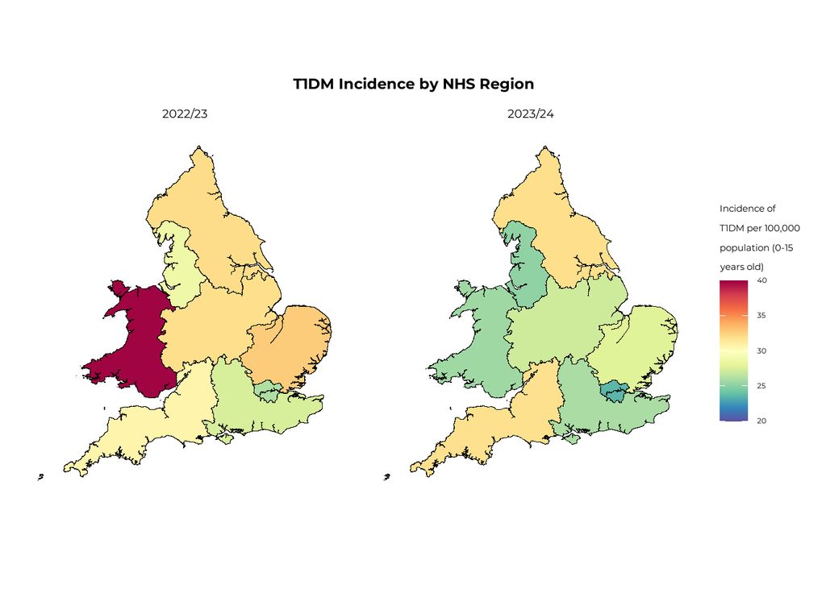

## 1.4 Characteristics of children and young people with Type 2 diabetes

In 2023/24, there were 1,359 children and young people with Type 2 diabetes being cared for in a PDU, of whom 292 (21.5%) were newly diagnosed within the audit year. Prevalence and/or incidence rates of Type 2 diabetes cannot be accurately calculated from NPDA data as an unknown number of children and young people are treated for Type 2 diabetes in primary care and will therefore not be included in the paediatric audit. Refer to the Type 2 diabetes audit from the NPDA and NDA for accurate numbers for these age ranges.[^5] [^6]

There appears to be a year-on-year increase in the number of children and young people with Type 2 diabetes being managed within PDUs. For instance, in 2023/24 there was an increase of 114 (9.2%) compared to the total number reported for the 2022/23 audit year. Figure 11 shows the numbers of children and young people with Type 2 diabetes being managed within a PDU since 2011/12.

**Figure 11:** Numbers of children and young people with Type 2 diabetes included in the NPDA, 2011/12 to 2023/24

[interactive chart not shown]

### 1.4.1 Age and sex

Figure 12 shows the age and sex breakdown of children and young people with Type 2 diabetes. The numbers start to fall from the age of 16 as young people transition to adult services. In every age category there is a higher proportion of girls with Type 2 diabetes. Figure 12 also shows that there were lower numbers of young people with Type 2 diabetes aged 14 receiving care from PDUs in 2023/24 compared to 2022/23, whereas in those aged 15, there were higher numbers in 2023/24.

**Figure 12:** Numbers of children and young people with Type 2 diabetes by age and sex, 2022/23 and 2023/24

[interactive chart not shown]

### 1.4.2 National distribution

Table 5 shows the number of children and young people with Type 2 diabetes by country, based on the location of the last PDU attended.

**Table 5:** Number of children and young people with Type 2 diabetes by country, 2023/24

| Country | 0-4 years | 5-9 years | 10-14 years | 15-19 years | 20-24 years | Total | % of cohort |
| --- | --- | --- | --- | --- | --- | --- | --- |
| England and Wales | 5 | 31 | 477 | 846* |  | 1359 | 100% |
| England | 5 | 29 | 460 | 829* |  | 1323 | 97.4% |
| Wales | 0 |  | 19* | 17 | 0 | 36 | 2.6% |

* Results merged to mask numbers <4

### 1.4.3 Ethnicity

Table 6 shows the breakdown of children and young people with Type 2 diabetes by ethnic category. The percentage of the general population in each ethnic category according to the most recent census[^7] is presented to enable comparison of prevalence of Type 2 diabetes within each category. Most children and young people with Type 2 diabetes were of non-White ethnicity, and the prevalence of Type 2 diabetes in children of non-White ethnicity is disproportionately higher than the prevalence of non-White ethnicity in the general population. The breakdown in 2023/24 was similar compared to 2022/23.

**Table 6:** Children and young people with Type 2 diabetes in England and Wales by ethnic group, 2023/24

| Ethnicity | No. of children and young people with T1 diabetes | % of cohort | % of total with stated ethnicity | % of total population* |
| --- | --- | --- | --- | --- |
| White | 494 | 36.4% | 40.1% | 81.7% |
| Asian** | 422 | 31.1% | 34.3% | 9.3% |
| Black | 185 | 13.6% | 15% | 4% |
| Mixed | 71 | 5.2% | 5.8% | 2.9% |
| Other | 60 | 4.4% | 4.9% | 2.1% |
| Not stated | 60 | 4.4% | - | - |
| Not known | 67 | 4.9% | - | - |

* Percentage of total population in 2021 England and Wales Census  
** Chinese ethnicity census data has been included in the “Other” category to align with NHS data dictionary standards

### 1.4.4 Deprivation

**Table 7:** Numbers and percentages of children and young people with Type 2 diabetes by deprivation quintile, 2023/24

| Deprivation quintile | No. of children and young people with T2 diabetes | % of cohort | % of total with known deprivation* | % of children and young people aged 0-19 years old (England and Wales)** |
| --- | --- | --- | --- | --- |
| Most deprived | 584 | 43% | 43.3% | 23.7% |
| Second most deprived | 367 | 27% | 27.2% | 20.7% |
| Third least deprived | 198 | 14.6% | 14.7% | 19% |
| Second least deprived | 105 | 7.7% | 7.8% | 18.1% |
| Least deprived | 94 | 6.9% | 7% | 18.5% |
| Missing | 11 | 0.8% | - | - |

* Percentages within deprivation quintiles have been calculated excluding those without an allocated quintile due to missing data, to allow comparison to the age group 0-19 years old in England and Wales, 2020  
** Percentage of general population aged 0 to 19 years old in England and Wales. Calculations made using the “Lower layer Super Output Area population estimates” from the Office for National Statistics, mid-year 2020

# 2 Completion of annual health checks

## 2.1 Completion of health checks for children and young people with Type 1 diabetes

### 2.1.1 Completion of key health checks

Health checks recommended by NICE for children and young people with Type 1 diabetes ([NG18, NICE 2015](https://www.nice.org.uk/guidance/ng18); [NG19, 2015](https://www.nice.org.uk/guidance/ng19)) should be performed at least once annually.

Prior to 2020/21 the NPDA reported on the following seven to be the ‘key’ annual checks:

- Glycated Haemoglobin A1c (HbA1c) (blood test correlated to glucose levels over a 3-month period and related to risk of long-term diabetes complications)
- Body Mass Index (BMI) (measure of cardiovascular risk)
- Blood pressure (measure of cardiovascular risk)
- Urinary albumin (urine test for kidney function, measure of microvascular risk)
- Thyroid screen (blood test for hyper/hypothyroidism)
- Eye screening (photographic test for microvascular eye (retinopathy) risk)
- Foot examination (foot examination for neuropathic risk)

From the 2020/21 audit year onwards, retinopathy screening reduced from an annual to a biennial schedule, unless retinopathy was observed at a previous screen, for many services in England and Wales. In view of this change, and in line with the 2020/21 audit, the NPDA now describes six key annual checks, excluding retinopathy screening.

Guidelines specify a starting age of 12 years for commencing all checks except for HbA1c and measurement of height and weight, which should be recorded in all ages of children and young people with Type 1 diabetes, and thyroid screening, which should be performed at diagnosis and annually thereafter.

In 2023/24, there were 26987 children and young people with Type 1 diabetes who completed a full year of care (i.e. who did not transition to adult services, did not die, and were not diagnosed within the audit year), of whom 16240 (60.2%) were aged 12 years and above.

Table 8 shows the percentage of children and young people recorded as receiving key healthcare checks in the audit year, from 2015/16 to 2023/24.

**Table 8:** Percentage of children and young people with Type 1 diabetes who completed a full year of care recorded as receiving health checks, 2015/16 to 2023/24

| Age | Measure | 2015/16 | 2016/17 | 2017/18 | 2018/19 | 2019/20 | 2020/21 | 2021/22 | 2022/23 | 2023/24 |
| --- | --- | --- | --- | --- | --- | --- | --- | --- | --- | --- |
| All ages | No. of children and young people with T1 diabetes (n) | 22,567 | 22,933 | 23,130 | 23,223 | 22,638 | 24,138 | 24,989 | 26,297 | 26,987 |
|  | HbA1c (%) | 99.2 | 99.5 | 99.4 | 99.4 | 99.7 | 90.6 | 98.3 | 99.1 | 99.3 |
|  | BMI (%) | 97.9 | 98.7 | 98.9 | 99.2 | 99.3 | 78.6 | 96.7 | 98.4 | 98.6 |
|  | Thyroid (%) | 77.7 | 81.8 | 84.0 | 87.2 | 87.8 | 77.9 | 84.1 | 86.3 | 87.8 |
| 12 years or older | No. of young people with T1 diabetes (n) | 13,313 | 13,437 | 13,363 | 13,391 | 13,266 | 14,449 | 15,009 | 15,709 | 16,240 |
|  | Blood Pressure (%) | 90.8 | 92.7 | 94.6 | 96.2 | 96.5 | 70.4 | 92.4 | 94.2 | 95.8 |
|  | Urinary Albumin (%) | 66.0 | 68.7 | 74.3 | 78.3 | 79.1 | 64.4 | 75.5 | 76.8 | 78.5 |
|  | Foot Exam (%) | 65.8 | 72.8 | 78.2 | 82.5 | 84.3 | 57.1 | 78.7 | 82.2 | 83.8 |
|  | All seven health checks (%)* | 35.5 | 43.5 | 49.8 | 55.2 | 54.4 | - | - | - | - |
|  | All six health checks (%)** | - | - | - | - | - | 40.2 | 59.7 | 63.4 | 66.4 |

* Includes retinal screening - one of the key annual checks until 2020/21  
** Excludes retinal screening due to change in screening interval for 2020/21 to 2023/24

Figure 13 shows completion rates from 2004/05 up until 2023/24. Comparisons of completion rates prior to 2015/16 should be made with caution as they included children with all types of diabetes. However, given that most children and young people reported to the audit have Type 1 diabetes, the improvements in completion rates are likely to reflect real improvements in health check completion and/or completeness of data submitted to the NPDA.

[interactive chart not shown]

**Figure 13:** Percentage of children and young people who completed a full year of care recorded as receiving individual health checks, 2004/05 to 2023/24

* Health checks completed on children and young people aged 12 or older  
** Cholesterol no longer a health check for Type 1 after 2014/15  
*** Excludes eye screening for 2020/21-2023/24

Figure 14 shows further improvement in the proportion of all children with Type 1 diabetes completing a year of care in 2023/24 receiving all six key annual healthcare checks since the pandemic year.

[interactive chart not shown]

**Figure 14:** Percentage of young people aged 12 or above who completed a full year of care recorded as receiving all seven/six key annual health checks, 2004/05 to 2023/24

* Retinopathy screening was removed from the seven key health checks analysis in 2020/21 due to changes in frequency of screening during this audit year. The percentage receiving all of the remaining six key annual checks is presented instead for these audit years

### 2.1.2 Retinopathy screening

Retinopathy screening intervals changed for many services in England and Wales in 2020/21. Rather than screening all those with diabetes aged 12 and above annually, many were advised to screen biennially unless an abnormal result was observed at a previous annual screen. In 2023/24, 69.1% of children and young people with Type 1 diabetes aged 12 and above received a screen, an increase from 68% in 2022/23.

In 2022/23, 1277 young people with Type 1 diabetes had an abnormal eye screen recorded, of whom 1049 were also captured in the 2023/24 audit dataset. A further 791 had a complete year of care in the current audit. Figure 15 shows that 72.8% of those who had an abnormal eye screen result in 2022/23 had an eye screen in 2023/24. This percentage is similar to the percentage of those with a normal retinopathy result recorded in 2022/23 who also received an eye screen in 2023/24 and is below the target (100%) screening rate for those with known retinopathy.

[interactive chart not shown]

**Figure 15:** Percentage of children and young people aged 12 and above in 2022/23 receiving retinopathy screening in 2023/24, by screening result in 2022/23

### 2.1.3 Variation in key health check completion

#### 2.1.3.1 Variation in completion rates nationally

**Table 9:** Percentage of children and young people with Type 1 diabetes who completed a full year of care recorded as having received health checks in England, Wales and overall, 2023/24

| Age | Measure | England and Wales | England | Wales |
| --- | --- | --- | --- | --- |
| All ages | No. of children and young people with T1 diabetes (n) | 26,987 | 25,688 | 1,299 |
|  | HbA1c (%) | 99.3 | 99.2 | 99.7 |
|  | BMI (%) | 98.6 | 98.6 | 99.2 |
|  | Thyroid (%) | 87.8 | 87.7 | 90.9 |
| 12 years or older | No. of young people with T1 diabetes (n) | 16,240 | 15,527 | 713 |
|  | Blood Pressure (%) | 95.8 | 95.8 | 95.8 |
|  | Urinary Albumin (%) | 78.5 | 78.1 | 86.3 |
|  | Foot Exam (%) | 83.8 | 83.4 | 92.0 |
|  | All six health checks (%)** | 66.4 | 65.9 | 79.0 |

#### 2.1.3.2 Variation in completion rates across PDUs

Figure 16 shows the percentage of eligible children and young people with Type 1 diabetes receiving each specific key annual health check by PDU from least to most completed in 2023/24.

[interactive chart not shown]

**Figure 16:** Percentage of children and young people with Type 1 diabetes receiving each key health check by PDU,2023/24

Figure 17 shows the variation by PDU in the percentage of young people aged 12 years and above who were recorded to have received all six key health checks in 2023/24. There remains considerable variation in percentage of young people receiving all six health checks across PDUs.

[interactive chart not shown]

**Figure 17:** Percentage of young people aged 12 years and above with Type 1 diabetes who completed a full year of care recorded as receiving all six health checks by PDU, 2023/24

Figure 18 plots the PDU health check completion rates against the total number of children and young people with Type 1 diabetes who completed a full year of care in each PDU. The health check completion rate is calculated in the following way, and only includes children and young people with Type 1 diabetes who have had a complete year of care:

$$\text{Total number of health checks received by children and young people of all ages} \choose (\text{Number of children aged 11 and below} * 3) + (\text{Number of young people ages 12 and above} ∗ 6)$$
This metric is used in the NPDA to determine outlier status, with PDUs below the bottom finely dotted line (3rd percentile) considered ‘alarm’ outliers, as they are delivering significantly fewer key health checks than other PDUs in England and Wales.

[interactive chart not shown]

**Figure 18:** Key health check completion rates for children and young people with Type 1 diabetes who completed a full year of care 2023/24, by PDU

### 2.1.4 Number of HbA1c measurements recorded

[NICE 2015 (NG18)](https://www.nice.org.uk/guidance/ng18) recommends that a minimum of four HbA1c measurements are offered to children and young people with Type 1 diabetes per annum. Figure 19 shows the percentage of children and young people with Type 1 diabetes receiving a full year of care by number of HbA1c measurements received in the audit year. It shows that the percentage of children and young people with Type 1 diabetes receiving four or more measurements (46.7%) was slightly higher than that recorded in 2022/23 (43.5%), while still below the levels seen prior to the 2020/21 pandemic audit year.

[interactive chart not shown]

**Figure 19:** Percentage of children and young people with Type 1 diabetes who completed a full year of care by number of HbA1c measurements recorded per child or young person, 2016/17 to 2023/24

Table 10 shows the percentage of children and young people with Type 1 diabetes receiving a full year of care by number of HbA1c measurements in England and Wales taken together and separately.

**Table 10:** Percentage of children and young people with Type 1 diabetes who completed a full year of care by number of HbA1cs measurements recorded in England and Wales combined and by each country, 2023/24

| Country | Total | None (%) | One (%) | Two (%) | Three (%) | Four+ (%) |
| --- | --- | --- | --- | --- | --- | --- |
| England and Wales | 26,987 | 0.7 | 5.1 | 15.3 | 32.2 | 46.7 |
| England | 25,688 | 0.8 | 5.3 | 15.4 | 31.9 | 46.7 |
| Wales | 1,299 | 0.3 | 2.3 | 12.5 | 37.3 | 47.6 |

### 2.1.5 Nutrition and lifestyle education and support

NICE (NG18) recommends offering children and young people with diabetes dietetic support to help optimise body weight and blood glucose control (NICE, 2015), and NHS England’s Best Practice Tariff criteria for paediatric diabetes care (NHS England, 2022) include the offering of an additional dietetic appointment outside of MDT clinic meetings. A lower take up rate of dietetic appointments outside of appointments with the rest of the MDT should be interpreted with caution, as it could reflect satisfaction with the advice shared during routine MDT appointments rather than a lack of engagement with the service.

Of those children and young people with Type 1 diabetes who completed a full year of care, 87.8% were offered an additional dietetic appointment, compared to 88.1% in 2022/23. Table 11 shows the percentages who were offered an additional appointment and attended the offered appointment within the audit year in England and Wales taken together and subdivided by each country.

**Table 11:** Percentage of children and young people with Type 1 diabetes who completed a full year of care who were offered and/or attended an additional dietetic appointment in England and Wales combined and by each country, 2023/24

| Country | Total | Appointment offered (%) | Appointment attended (%) |
| --- | --- | --- | --- |
| England and Wales | 26987 | 87.8 | 50.2 |
| England | 25688 | 88.0 | 50.2 |
| Wales | 1299 | 82.6 | 51.2 |

The percentage of appointments attended decreased with age and duration of diabetes, from 54.6% of those four years old or younger to 44.1% in the group aged 15 years old or older (Figure 20).

[interactive chart not shown]

**Figure 20:** Percentage of offered dietetic appointments attended by age group and duration of diabetes, 2023/24

### 2.1.6 Completion of all other annual health checks

The NPDA also collects data on five additional health checks for children and young people with Type 1 diabetes as recommended by NICE 2015 (NG18):

- Psychological assessment (assessment for need of psychological support)
- Offering of immunisation against influenza
- Advice about managing diabetes (‘sick-day rules’)
- Using (or trained to use) blood ketone testing strips and a meter
- Smoking status check

Results are shown in Table 12

**Table 12:** Percentage of children and young people with Type 1 diabetes who completed a full year of care recorded as receiving health checks in England and Wales combined and by each country, 2023/24

| Age | Measure | England and Wales | England | Wales |
| --- | --- | --- | --- | --- |
| All ages | Number of children and young people all ages (n) | 26987.0 | 25688.0 | 1299.0 |
|  | Flu vaccine recommended (%) | 89.4 | 89.0 | 98.1 |
|  | Sick day rules (%) | 90.6 | 90.4 | 95.8 |
|  | Blood ketone testing (%) | 90.2 | 89.8 | 98.4 |
|  | Psychological assessment (%) | 81.8 | 82.1 | 75.2 |
| 12 years or older | Number of young people 12 years or older (n) | 16240.0 | 15527.0 | 713.0 |
|  | Smoking health check (%)* | 90.6 | 90.1 | 99.9 |

* Percentage of young people aged 12 and above with Type 1 diabetes

Approximately 3.7% of young people were recorded as smoking within the audit year and of those, 27.6% were offered a referral to smoking cessation services, compared to 42.9% in 2022/23. The proportion of current smokers was higher in boys (4%) than girls (3.4%), and lower among those living in the most deprived areas (3.2%) than in the least deprived areas (3.5%).

Figure 21 shows that similar proportions of children and young people with Type 1 diabetes were offered flu vaccination, “Sick day rules” advice and blood ketone testing in the 2023/24 audit year as in the 2022/23 audit year.

[interactive chart not shown]

**Figure 21:** Completion rates for psychological assessment, flu vaccine recommendation, “Sick day rules” advice and blood ketone testing, for children and young people with Type 1 diabetes who completed a full year of care, 2017/18 to 2023/24

### 2.1.7 Care at diagnosis

#### 2.1.7.1 Screening for autoimmune conditions

Children and young people with Type 1 diabetes are at greater risk of having other autoimmune conditions. [NG18 (NICE, 2015)](https://www.nice.org.uk/guidance/ng18) and [NG20 (NICE, 2015)](https://www.nice.org.uk/guidance/ng20) recommend screening for thyroid and coeliac disease at diagnosis.

Figure 22 shows the percentage of children and young people diagnosed more than 90 days before the end of the audit year (n=2,365), who received screening for coeliac and thyroid disease within 90 days of diagnosis. In 2023/24, completion of both health checks at diagnosis were at their highest rates seen in recent years.

[interactive chart not shown]

**Figure 22:** Percentage of newly diagnosed children and young people with Type 1 diabetes who received screening for thyroid and coeliac disease within 90 days of diagnosis, 2015/16 to 2023/24

#### 2.1.7.2 Level 3 carbohydrate counting

NICE guidance ([NG18, NICE 2015](https://www.nice.org.uk/guidance/ng18)) recommends offering level 3 carbohydrate-counting education to children and young people with Type 1 diabetes from diagnosis.

Figure 23 shows the percentage of children and young people diagnosed more than 14 days before the end of the audit year (n= 3,135) who received level 3 carbohydrate-counting education within 14 days of diagnosis from 2017/18 to 2023/24.

[interactive chart not shown]

**Figure 23:** Percentage of newly diagnosed children and young people with Type 1 diabetes who received level 3 carbohydrate counting education within 14 days of diagnosis, 2017/18 to 2023/24

## 2.2 Health checks for children and young people with Type 2 diabetes

The health checks for children and young people with Type 2 diabetes recommended in [NG18](https://www.nice.org.uk/guidance/ng18) and [NG19](https://www.nice.org.uk/guidance/ng19) (NICE, 2015) differ slightly from those for Type 1 diabetes. The NPDA includes cholesterol screening as one of the six essential annual checks for those with Type 2 rather than thyroid screening. All should be performed annually from diagnosis, except for foot examination, which is indicated from age 12, and eye screening, which is also indicated from 12, and indicated biannually from 2020 onwards (previously annually). In 2023/24, there were 852 children and young people who completed a full year of care (i.e. were not diagnosed, did not die and did not transition to adult services within the audit year) recorded as having Type 2 diabetes, of whom 807 (94.7%) were aged 12 years and above.

### 2.2.1 Completion of key health checks

Figure 24 shows the percentage of children and young people with Type 2 diabetes who completed a full year of care recorded as receiving each of the six recommended health checks from 2015/16 to 2023/24.

[interactive chart not shown]

**Figure 24:** Percentage of children and young people with Type 2 diabetes who completed a full year of care recorded as receiving key annual health checks, 2015/16 to 2023/24

* Health check for those aged 12 and over  
** Retinal screening excluded since 2020/21 due to change in screening frequency

Table 13 shows the percentage of children and young people with Type 2 diabetes recorded as receiving recommended key annual health checks in the audit year, from 2015/16 to 2023/24.

**Table 13:** Percentage of children and young people with Type 2 diabetes who completed a full year of care recorded as receiving recommended health checks, 2015/16 to 2023/24

| Age | Measure | 2015/16 | 2016/17 | 2017/18 | 2018/19 | 2019/20 | 2020/21 | 2021/22 | 2022/23 | 2023/24 |
| --- | --- | --- | --- | --- | --- | --- | --- | --- | --- | --- |
| All ages | No. of children and young people (n) | 412 | 473 | 470 | 501 | 534 | 618.0 | 694.0 | 809.0 | 852.0 |
|  | HbA1c (%) | 97.3 | 96.6 | 96.8 | 97.8 | 95.3 | 82.7 | 92.1 | 94.2 | 95.2 |
|  | BMI (%) | 94.4 | 94.1 | 94.5 | 95 | 94.2 | 69.1 | 87.9 | 91.7 | 91.8 |
|  | Cholesterol (%) | 59.2 | 66.4 | 67.9 | 70.5 | 64.4 | 58.3 | 61.1 | 64.3 | 61.7 |
|  | Blood pressure (%) | 85 | 86 | 88.5 | 90.9 | 89.6 | 63.1 | 82.1 | 85.0 | 89.0 |
|  | Urinary albumin (%) | 51.7 | 56.7 | 58.9 | 62.1 | 62.1 | 48.9 | 56.1 | 58.2 | 56.8 |
| Aged 12 and above | No. of young people (n) | 390 | 436 | 436 | 470 | 499 | 577.0 | 654.0 | 749.0 | 807.0 |
|  | Foot exam (%)* | 50 | 50.2 | 61.7 | 67 | 65.1 | 40.4 | 57.2 | 63.7 | 63.7 |
|  | All 6 care processes (%)** |  |  |  |  |  | 24.1 | 33.0 | 35.5 | 36.8 |

### 2.2.2 Number of HbA1c measurements

[interactive chart not shown]

**Figure 25:** Number of HbA1c measurements recorded for children and young people with Type 2 diabetes receiving a full year of care, 2016/17 to 2023/24

### 2.2.3 Completion of all other health checks

Table 14 shows the percentage of children and young people with Type 2 diabetes completing a full year of care (n= 852) recorded as being offered and attending an additional dietetic appointment outside of routine MDT clinics with the rest of the MDT present. Lower uptake may be indicative of satisfaction with advice provided in routine clinics rather than lack of engagement with dietetic services.

**Table 14:** Percentage of children and young people with Type 2 diabetes who completed a full year of care recorded as being offered and attending an additional dietetic appointment, 2017/18 to 2023/24

| Measure | 2017/18 | 2018/19 | 2019/20 | 2020/21 | 2021/22 | 2022/23 | 2023/24 |
| --- | --- | --- | --- | --- | --- | --- | --- |
| Appointment offered (%) | 70.0 | 80.0 | 80 | 78.3 | 78.7 | 81.2 | 81.7 |
| Appointment attended (%) | 48.7 | 48.5 | 56 | 71.9 | 57.3 | 53.6 | 51.2 |

The NPDA also collects data on four additional health checks for children and young people with Type 2 diabetes:

- Psychological assessment (assessment for need of psychological support)
- Offering of immunisation against influenza
- Advice about managing diabetes during sickness (‘sick day rules’)
- Smoking status

Results are shown in Table 15 for all children and young people with type 2 diabetes and a complete year of care (n= 852).

**Table 15:** Percentage of young people with Type 2 diabetes who completed a full year of care recorded as receiving health checks by country, 2017/18 to 2023/24

| Measure | 2017/18 | 2018/19 | 2019/20 | 2020/21 | 2021/22 | 2022/23 | 2023/24 |
| --- | --- | --- | --- | --- | --- | --- | --- |
| Assessment for need of psychological support (%) | 77.9 | 75.0 | 70.8 | 60.5 | 70.5 | 72.4 | 64.8 |
| Flu vaccine recommendation (%) | 49.4 | 69.3 | 67.8 | 63.3 | 70.5 | 71.3 | 70.9 |
| Sick day rules advice (%) | 41.7 | 51.5 | 53.0 | 48.5 | 52.7 | 57.8 | 60.1 |
| Smoking status check (%)* | 85.3 | 84.3 | 85.0 | 83.7 | 85.9 | 80.6 | 82.0 |

* Percentage of children and young people aged 12 and above

# 3 Outcomes

## 3.1 HbA1c

In 2015, NICE ([NG18, 2015](https://www.nice.org.uk/guidance/ng18)) introduced a lower HbA1c target of 48mmol/mol or less to indicate excellent diabetes management for both Type 1 and 2 diabetes and requested that providers also report those achieving a level of 53 mmol/mol or below. To allow historical benchmarking, the NPDA also reports the numbers achieving the previous NICE (2004) target of 58 mmol/mol or below and an HbA1c level above 80mmol/mol representing considerable increased risk of both microvascular diabetic complications (eye disease and kidney disease) and cardiovascular disease.

Average HbA1c and the proportion of children and young people meeting specific HbA1c targets vary depending on the type of diabetes. Children and young people with non-Type 1 diabetes tend to have a lower HbA1c than those with Type 1 diabetes. Some of the data presented below refer to children and young people with all types of diabetes whilst other sections detail the results of those with Type 1 or Type 2 diabetes separately. Numbers of children and young people with other types of diabetes were too low to enable meaningful analysis.

This section of the report seeks to answer the following audit questions:

1. What are the average HbA1c levels and percentage of children and young people with diabetes hitting targets in England and Wales for 2023/24,
2. What are the influences of deprivation and ethnicity, and
3. What are the longitudinal changes?

## 3.2 HbA1c outcomes of children and young people with all types of diabetes

### 3.2.1 National unadjusted HbA1c results (all types of diabetes)

Table 16 shows the unadjusted mean and median HbA1c results for children and young people with all types of diabetes in England and Wales.

**Table 16:** HbA1c for all children and young people in England and Wales with one or more valid HbA1c measurement by type of diabetes, 2023/24

| Diabetes Type | No. of CYP | Mean (mmol/mol) | Median (mmol/mol) | Standard deviation (mmol/mol) | Interquartile Range (mmol/mol) |
| --- | --- | --- | --- | --- | --- |
| Type 1 | 30844 | 63.5 | 60.0 | 16.1 | 17.0 |
| Type 2 | 1145 | 58.7 | 50.0 | 23.9 | 29.0 |
| Cystic fibrosis-related diabetes | 145 | 44.5 | 40.0 | 15.4 | 7.0 |
| Monogenic forms of diabetes | 164 | 53.0 | 49.0 | 15.7 | 15.1 |
| Other specified forms of diabetes | 370 | 57.4 | 54.3 | 18.9 | 25.0 |
| Not specified diabetes melitus | 67 | 58.9 | 53.0 | 20.4 | 24.0 |

## 3.3 HbA1c outcomes of children and young people with Type 1 diabetes

### 3.3.1 National unadjusted HbA1c results (Type 1 diabetes)

Figure 26 shows that the median HbA1c for 2023/24 was 60.5 mmol/mol in England and60 mmol/mol in Wales, and that there has been a gradual decrease in median HbA1c for both England and Wales since 2010/11.

**Figure 26:** Median HbA1c for children and young people with Type 1 diabetes in England and Wales, 2010/11 to 2023/24

[interactive chart not shown]

Table 17 shows the unadjusted mean and median HbA1c results for children and young people with Type 1 diabetes achieved by country in 2023/24. The unadjusted mean HbA1c was 63.5 mmol/ mol, which is an increase of 0.1 mmol/mol from 2022/23. The median HbA1c was 60 mmol/mol, a decrease of 0.5 mmol/mol from 2022/23.

**Table 17:** HbA1c for all children and young people with Type 1 diabetes with one or more valid HbA1c measurement by country 2023/24

| Country | No. of CYP | Mean (mmol/mol) | Median (mmol/mol) | Standard deviation (mmol/mol) | Interquartile Range (mmol/mol) |
| --- | --- | --- | --- | --- | --- |
| England and Wales | 30844 | 63.5 | 60.0 | 16.1 | 17 |
| England | 29302 | 63.5 | 60.5 | 16.1 | 17 |
| Wales | 1542 | 62.8 | 60.0 | 15.3 | 16 |

Figure 27 shows the percentages of children and young people with Type 1 diabetes achieving each of the NICE (2015) treatment targets from 2014/15 to 2023/24.

[interactive chart not shown]

**Figure 27:** Percentage of children and young people with Type 1 diabetes with an HbA1c result within current and previous target ranges, 2014/15 - 2023/24

Table 18 presents the same information for England and Wales combined, as well as separately by country.

**Table 18:** Percentage of children and young people with Type 1 diabetes achieving HbA1c targets by country, 2023/24

| Country | ≤48 mmol/mol (%) | ≤53 mmol/mol (%) | ≤58 mmol/mol (%) | 58-80 mmol/mol (%) | ≥69 mmol/mol (%) | ≥75 mmol/mol (%) | ≥80 mmol/mol (%) |
| --- | --- | --- | --- | --- | --- | --- | --- |
| England and Wales | 11.9 | 25.6 | 40.7 | 47.4 | 27.2 | 16.7 | 11.9 |
| England | 11.9 | 25.6 | 40.6 | 47.4 | 27.3 | 16.7 | 12.0 |
| Wales | 11.5 | 25.8 | 42.9 | 46.4 | 25.4 | 15.6 | 10.7 |

### 3.3.2 HbA1c outcomes by sex (Type 1 diabetes)

Figure 28 shows that the mean HbA1c has decreased at a similar rate for both boys and girls with Type 1 diabetes over the last 20 years. It also shows that girls have had a consistently higher mean HbA1c than boys.

[interactive chart not shown]

**Figure 28:** Mean HbA1c for boys and girls with Type 1 diabetes, 2003/04 to 2023/24

### 3.3.3 HbA1c outcomes by age and duration of diabetes (Type 1 diabetes)

Figure 29 shows mean unadjusted HbA1c by duration of diabetes in 2023/24. Children and young people of all age groups had higher HbA1c from two years following diagnosis, except for those aged 0-4 years. After the first year following diagnosis, those aged 15-19 had consistently higher HbA1c than other age groups.

[interactive chart not shown]

**Figure 29:** Mean HbA1c for children and young people with Type 1 diabetes in England and Wales by duration of diabetes and age group, 2023/24

### 3.3.4 HbA1c outcomes by ethnicity (Type 1 diabetes)

Figure 30 shows that whilst there have been overall improvements in the average HbA1c amongst children and young people with Type 1 diabetes in all ethnic categories since 2011/12, there have been consistent differences in HbA1c outcomes between those in different ethnic categories, with those of White and Other ethnicities having lower average HbA1cs and those of Black ethnicity having the highest average HbA1c year on year.

[interactive chart not shown]

**Figure 30:** Mean HbA1c for children and young people with Type 1 diabetes in England and Wales by ethnic group, 2003/04 to 2023/24

**Table 19:** Mean HbA1c for children and young people with Type 1 diabetes by ethnic category and deprivation quintile, 2023/24

| Ethnic group | Most deprived | Second most deprived | Third least deprived | Second least deprived | Least deprived |
| --- | --- | --- | --- | --- | --- |
| White | 66.2 | 64.6 | 63.1 | 61.7 | 59.9 |
| Asian | 65.9 | 64.7 | 63.1 | 61.3 | 58.6 |
| Black | 71.0 | 71.6 | 69.3 | 69.6 | 68.3 |
| Mixed | 67.4 | 68.1 | 65.0 | 64.0 | 62.0 |
| Other | 64.9 | 64.5 | 63.7 | 60.7 | 61.1 |
| Not stated | 65.3 | 64.2 | 61.7 | 59.7 | 59.6 |
| Not known | 65.3 | 62.6 | 57.8 | 61.4 | 57.5 |

Figure 31 shows the percentage of children and young people with Type 1 diabetes meeting HbA1c treatment targets. It shows that results of those of White or Other ethnicity skew towards the lower targets, whereas those of Black or Mixed ethnicity skew above these targets.

[interactive chart not shown]

**Figure 31:** Percentage of children and young people with Type 1 diabetes in England and Wales achieving HbA1c targets by ethnic group, 2023/24

### 3.3.5 HbA1c outcomes by deprivation quintile (Type 1 diabetes)

NPDA results have consistently shown an association between higher HbA1c and living in more deprived areas. Figure 32 shows that in 2023/24 there was a reduction in mean HbA1c within each deprivation quintile compared to 2022/23, except for the second least deprived quintile which remained stable.

[interactive chart not shown]

**Figure 32:** Mean HbA1c for children and young people with Type 1 diabetes by deprivation quintile, 2013/14 to 2023/24

Figure 33 shows the percentages of children and young people with Type 1 diabetes achieving treatment targets by deprivation quintile. Results of those in the least deprived areas skewed towards lower targets, whereas those of children and young people living in the most deprived areas skewed towards the higher cut-offs.

[interactive chart not shown]

**Figure 33:** Percentage of children and young people with Type 1 diabetes in England and Wales achieving HbA1c targets by deprivation quintile, 2023/24

### 3.3.6 HbA1c outcomes across PDUs in England and Wales (Type 1 diabetes)

Figure 34 shows the mean HbA1c value for all PDUs in England and Wales , along with the national average (63.5 mmol/mol) and 95% confidence intervals for each unit. mean HbA1c values by PDU ranged from 56.3 mmol/mol to 74.3 mmol/mol.

[interactive chart not shown]

**Figure 34:** Mean HbA1c per paediatric diabetes unit (PDU), 2023/24

Figure 35 shows the percentage of children and young people with Type 1 diabetes achieving the HbA1c target of <58 mmol/mol by PDU, along with 95% confidence intervals for each unit. The overall percentage achieving this target was 40.7% (41% in 2022/23). The percentages achieving this target per PDU ranged from 15.5% to 63.8%.

[interactive chart not shown]

**Figure 35:** Percentage of children and young people with HbA1c <58mmol/mol per paediatric diabetes unit (PDU) 2023/24

## 3.4 HbA1c outcomes of children and young people with Type 2 diabetes

[interactive chart not shown]

**Figure 36:** Median HbA1c for children and young people with Type 2 diabetes in England and Wales, 2015/16 to 2023/24

**Table 20:** HbA1c for all children and young people with Type 2 diabetes and one or more valid HbA1c measurements in England and Wales, 2015/16 - 2023/24

| Year | No. of CYP | Mean (mmol/mol) | Standard deviation (mmol/mol) | Median (mmol/mol) | Interquartile Range (mmol/mol) |
| --- | --- | --- | --- | --- | --- |
| 2015/16 | 539 | 59.7 | 25.4 | 51.0 | 30.5 |
| 2016/17 | 605 | 60.2 | 24.6 | 52.0 | 33.5 |
| 2017/18 | 650 | 61.3 | 25.3 | 53.0 | 28.5 |
| 2018/19 | 674 | 57.4 | 23.5 | 49.5 | 26.0 |
| 2019/20 | 731 | 58.6 | 23.6 | 51.0 | 28.0 |
| 2020/21 | 676 | 61.0 | 24.8 | 53.0 | 33.5 |
| 2021/22 | 929 | 58.5 | 23.1 | 50.0 | 27.5 |
| 2022/23 | 1056 | 58.2 | 24.0 | 49.2 | 28.0 |
| 2023/24 | 1145 | 58.7 | 23.9 | 50.0 | 29.0 |

[interactive chart not shown]

**Figure 37:** Percentage of children and young people with Type 2 diabetes with an HbA1c result within current and previous target ranges, 2017/18 - 2023/24

### 3.4.1 HbA1c outcomes by sex (Type 2 diabetes)

Figure 38 provides a breakdown of mean HbA1c amongst children and young people with Type 2 diabetes by sex in each audit year. It shows variation between the audit years, including an increase in mean HbA1c from the previous audit year (2022/23) for girls and a decrease in mean HbA1c for boys in the same timeframe.

[interactive chart not shown]

**Figure 38:** Mean HbA1c for boys and girls with Type 2 diabetes, 2017/18 to 2023/24

### 3.4.2 HbA1c outcomes by age group and duration of diabetes (Type 2 diabetes)

Figure 39 shows a trend of HbA1c increasing after the first year of diagnosis for children and young people with Type 2 diabetes.

[interactive chart not shown]

**Figure 39:** Mean HbA1c for children and young people with Type 2 diabetes, by age group and duration of diabetes, 2023/24

### 3.4.3 HbA1c outcomes by deprivation quintile (Type 2 diabetes)

Figure 40 shows variation in mean HbA1c by deprivation quintile across audit years. In the 2023/24 audit year, living in deprived areas is associated with an increase in mean HbA1c for Type 2 diabetes.

[interactive chart not shown]

**Figure 40:** Mean HbA1c for children and young people with Type 2 diabetes in England and Wales by deprivation quintile, 2015/16 to 2023/24

### 3.4.4 HbA1c outcomes by ethnic category (Type 2 diabetes)

Figure 41 shows that White children and young people with Type 2 diabetes had lower mean HbA1c than those in other ethnic categories. Black children and young people with Type 2 diabetes had higher mean HbA1c than those in other ethnic categories, a finding that is consistent with previous audit years.

[interactive chart not shown]

**Figure 41:** Mean HbA1c for children and young people with Type 2 diabetes by ethnic category, 2015/16-2023/24

## 3.5 Small vessel (microvascular) disease

People with diabetes are at increased risk of microvascular disease including diabetic kidney disease (nephropathy) and diabetic eye disease (retinopathy). This section explores the incidence and demographics of early signs of microvascular disease in children with diabetes.

### 3.5.1 Diabetic kidney disease

Annual urinary albumin screening is recommended by NICE (2015) in all children with Type 1 diabetes aged 12 and above, and for all those with Type 2 diabetes of any age. The presence of albuminuria may be indicative of progressive diabetic kidney disease.

#### 3.5.1.1 Albuminuria in young people with Type 1 diabetes

Approximately two-thirds (n = 14,086) of young people with Type 1 diabetes aged 12 years and above were recorded as receiving a urinary albumin screen during the audit period 2023/24. Please note that this number includes all children who had a urinary albumin level recorded during the audit period and is not restricted to those with a complete year of care, as it is in Chapter 2. Of those, 95.2% (n = 13,415) had a valid interpretation of the urinary albumin level. Increased risk of kidney disease is indicated by the presence of either micro- or macro-albuminuria. Figure 42 shows that 9.6% of young people in England and Wales with Type 1 diabetes were recorded as having micro- or macro-albuminuria.

[interactive chart not shown]

**Figure 42:** Percentage of young people with Type 1 diabetes aged 12 years and above with albuminuria in England and Wales combined, and in each country (2023/24)

Table 21 shows that the percentage of young people with Type 1 diabetes aged 12 years and above with albuminuria has not changed since 2015/16.

**Table 21:** Percentage of young people with Type 1 diabetes aged 12 years and above with albuminuria, 2015/16 to 2023/24

| Audit Year | Total (n) | Normo-albuminuria (%) | Micro- or macro- albuminuria (%) |
| --- | --- | --- | --- |
| 2015/16 | 9364 | 90.1 | 9.9 |
| 2016/17 | 9938 | 90.0 | 10.0 |
| 2017/18 | 10631 | 89.8 | 10.2 |
| 2018/19 | 11075 | 90.2 | 9.8 |
| 2019/20 | 11270 | 88.9 | 11.1 |
| 2020/21 | 9785 | 89.7 | 10.3 |
| 2021/22 | 12162 | 88.5 | 11.5 |
| 2022/23 | 12943 | 89.6 | 10.4 |
| 2023/24 | 13415 | 90.4 | 9.6 |

Figure 43 shows slight variations but no clear trend in the presence of albuminuria by duration of diabetes across the audit years. Please note that the group with a diabetes duration of 15 years or more is subject to greater variation due to a smaller sample size.

[interactive chart not shown]

**Figure 43:** Percentage of young people with Type 1 diabetes aged 12 years and above with albuminuria by duration of diabetes, 2016/17 - 2023/24

Figure 44 shows little difference in rates of albuminuria by age and sex, with boys having a marginally higher rate at every age.

[interactive chart not shown]

**Figure 44:** Percentage of young people with Type 1 diabetes aged 12 years and above with albuminuria by age and sex, 2016/17 - 2023/24

Figure 45 shows that the prevalence of albuminuria decreased moderately across all deprivation quintiles in 2023/24, and was slightly lower in the least deprived areas.

[interactive chart not shown]

**Figure 45:** Percentage of young people with Type 1 diabetes aged 12 years and above with albuminuria by deprivation quintile, 2016/17 - 2023/24

Figure 46 shows that among young people with Type 1 diabetes, those with micro or macroalbuminuria have a higher proportion with an HbA1c greater than 80 mmol/mol compared with those with normoalbuminuria. It also shows that albuminuria can occur even among individuals meeting the lower HbA1c targets.

[interactive chart not shown]

**Figure 46:** Percentage of young people with Type 1 diabetes achieving HbA1c targets by presence of albuminuria, 2023/24

[interactive chart not shown]

**Figure 46 (alternative):** Percentage of Normoalbuminuria and Micro/Macroalbuminuria in young people with Type 1 diabetes by HbA1c Target, 2023/24

#### 3.5.1.2 Albuminuria in children and young people with Type 2 diabetes

Figure 47 shows that micro or macroalbuminuria was present in 20.8% of young people aged 12 years or older with Type 2 diabetes who had a valid interpretation of their urinary albumin level (n=566) in 2023/24. The percentage of young people with Type 2 diabetes and albuminuria is twice that recorded for young people with Type 1 diabetes (9.6%) – indicating that children and young people with Type 2 diabetes are potentially at greater risk of kidney disease.

[interactive chart not shown]

**Figure 47:** Percentage of young people aged 12 years or older with Type 2 diabetes and micro or macroalbuminuria in England and Wales, 2015/16 - 2023/24

### 3.5.2 Eye disease

#### 3.5.2.1 Retinopathy in young people with Type 1 diabetes

There were 12,759 young people with Type 1 diabetes aged 12 years and above recorded as receiving an eye screen during the audit period. Of those, 98.6% (n = 12,578) had a valid eye screen result recorded. Table 22 shows that 11.2% of young people with Type 1 diabetes aged 12 and above had an abnormal eye screen result recorded within the audit period. This percentage is lower than the rates seen immediately prior to the pandemic, despite young people with known retinopathy being prioritized for screening in many areas since 2020/21, which could skew the results.

The NPDA only records an eye screen as being normal or abnormal. Most abnormal screens in this age group are likely to represent background - rather than progressive - retinopathy.

**Table 22:** Percentage of young people with Type 1 diabetes aged 12 years and above with a normal/abnormal eye screening result, 2015/16 to 2023/24

| Audit Year | Total (n) | Normal (%) | Abnormal (%) |
| --- | --- | --- | --- |
| 2015/16 | 9788 | 84.7 | 15.3 |
| 2016/17 | 9938 | 85.2 | 14.8 |
| 2017/18 | 11134 | 87.2 | 12.8 |
| 2018/19 | 11431 | 86.9 | 13.1 |
| 2019/20 | 10852 | 88.0 | 12.0 |
| 2020/21 | 4247 | 83.1 | 16.9 |
| 2021/22 | 10866 | 88.6 | 11.4 |
| 2022/23 | 12033 | 89.1 | 10.9 |
| 2023/24 | 12578 | 88.8 | 11.2 |

Figure 48 provides a breakdown of screening results in 2023/24 of all those who also had a recorded retinopathy screening result in 2022/23. It shows that of those with a normal result in 2022/23, 5.7% were found to have retinopathy in 2023/24, whilst 30.1% of those with retinopathy in 2022/23 had a normal result in 2023/24. If the young people without retinopathy in 2022/23 who were screened for retinopathy in 2023/24 are representative, these results suggest that moving to a biannual screening frequency could lead to similar percentages of young people missing a timely retinopathy diagnosis if biannual screening intervals are maintained.

[interactive chart not shown]

**Figure 48:** Retinopathy screening outcomes of young people aged 12 years and above with Type 1 diabetes in 2023/24 by result of screening 2022/23

#### 3.5.2.2 Retinopathy in young people with Type 2 diabetes

[interactive chart not shown]

**Figure 49:** Eye screening results for young people aged 12 years and above with Type 2 diabetes 2015/16 to 2023/24

## 3.6 Large vessel disease - Cardiovascular Disease (CVD) risk factors

People with diabetes are at an increased risk of cardiovascular disease secondary to macrovascular risk factors including high blood pressure, abnormal lipid levels and high body mass index. This chapter examines the prevalence of these risk factors, and patient characteristics associated with higher risk for them.

### 3.6.1 Blood pressure and cholesterol

High blood pressure and/or raised blood cholesterol increases lifetime risk of cardiovascular disease, including stroke and heart disease. In adults with Type 1 diabetes, maintaining normal blood pressure and cholesterol within target (less than 5 mmol/L) reduces this risk. Although screening of total cholesterol levels is no longer a mandatory requirement for children and young people with Type 1 diabetes following NICE guidance NG18 (2015), results are still presented where data have been submitted. Diastolic and systolic blood pressure measurements were converted to age- and sex-adjusted centiles using survey data between 1995 and 1998 from the general population aged between 4 and 24 years old (Jackson et al., 2007).

#### 3.6.1.1 Blood pressure and cholesterol in young people with Type 1 diabetes

Table 23 shows the percentages of young people aged 12 and above with Type 1 diabetes with a recorded blood pressure in the audit period (n=18,265) classified as having ‘high normal’ (91st -98th centile) or ‘high’ blood pressure (>98th centile) in England and Wales. Nearly a third of young people (28.4%) with Type 1 diabetes had high blood pressure (hypertension); a similar figure was reported in the 2022/23 audit (29.6%).

**Table 23:** Percentage of young people with Type 1 diabetes aged 12 years and above falling within blood pressure targets in England and Wales, 2023/24

| Country | 'High normal' blood pressure (91st–98th centile) Diastolic (%) | 'High normal' blood pressure (91st–98th centile) Systolic (%) | 'High normal' blood pressure (91st–98th centile) Diastolic and/or systolic (%) | 'High' blood pressure (>98th centile) Diastolic (%) | 'High' blood pressure (>98th centile) Systolic (%) | 'High' blood pressure (>98th centile) Diastolic and/or systolic (%) |
| --- | --- | --- | --- | --- | --- | --- |
| England and Wales | 30.7 | 7.8 | 31.5 | 27.5 | 2.8 | 28.4 |
| England | 30.5 | 7.7 | 31.3 | 27.4 | 2.8 | 28.3 |
| Wales | 34.7 | 8.8 | 35.1 | 30.2 | 2.5 | 31.5 |

Table 24 shows the percentages of young people aged 12 years and above with Type 1 diabetes who had a recorded cholesterol value during the audit year (n = 13,016), whose total blood cholesterol levels were 4 mmol/L or more and 5 mmol/L or more, by country. It shows that 18.7% exceeded the higher (≥5 mmol/L) target for total blood cholesterol. This figure is similar to the one reported in the 2022/23 audit (19.6%).

**Table 24:** Percentage of young people with Type 1 diabetes aged 12 years and above falling above cholesterol target ranges by country and overall, 2023/24

| Country | 4 mmol/L or more (%) | 5 mmol/L or more (%) |
| --- | --- | --- |
| England and Wales | 60.8 | 18.7 |
| England | 60.7 | 18.7 |
| Wales | 62.2 | 17.6 |

Figure 50 shows the percentages of young people aged 12 years and above with Type 1 diabetes with ‘high’ blood pressure (>98th centile) and the percentage above the target for total blood cholesterol (≥5 mmol/L) reported to the audit since 2013/14.

[interactive chart not shown]

**Figure 50:** Percentage of young people aged 12 years and above with Type 1 diabetes with high blood pressure and total blood cholesterol above targets in England and Wales, 2013/14 to 2023/24

#### 3.6.1.2 Blood pressure and cholesterol in young people with Type 2 diabetes

Table 25 shows the percentage of young people aged 12 years and above with Type 2 diabetes and a recorded blood pressure in the audit period (n=1,051) classified as ‘high normal’ (91st - 98th centile) or ‘high’ blood pressure (>98th centile). Nearly half (45.8%) of young people with Type 2 diabetes had high blood pressure.

**Table 25:** Percentage of young people aged 12 years and above with Type 2 diabetes and “high” or “high-normal” blood pressure, 2016/17 - 2023/24

| Year | 'High normal' blood pressure (91st–98th centile) Diastolic (%) | 'High normal' blood pressure (91st–98th centile) Systolic (%) | 'High normal' blood pressure (91st–98th centile) Diastolic and/or systolic (%) | 'High' blood pressure (>98th centile) Diastolic (%) | 'High' blood pressure (>98th centile) Systolic (%) | 'High' blood pressure (>98th centile) Diastolic and/or systolic (%) |
| --- | --- | --- | --- | --- | --- | --- |
| 2016/17 | 24.5 | 15.8 | 36.2 | 42.2 | 13.6 | 45.6 |
| 2017/18 | 22.2 | 17.0 | 34.1 | 42.7 | 13.1 | 44.9 |
| 2018/19 | 25.4 | 17.6 | 39.6 | 42.5 | 10.1 | 44.6 |
| 2019/20 | 28.3 | 16.1 | 26.8 | 42.8 | 10.4 | 44.3 |
| 2020/21 | 21.4 | 14.6 | 22.0 | 46.8 | 13.5 | 49.3 |
| 2021/22 | 24.2 | 16.3 | 25.7 | 44.5 | 12.0 | 46.7 |
| 2022/23 | 26.7 | 14.1 | 27.1 | 44.4 | 10.3 | 46.8 |
| 2023/24 | 24.5 | 15.1 | 25.5 | 44.0 | 9.5 | 45.8 |

Table 26 shows the percentage of young people aged 12 years and above with Type 2 diabetes and a recorded cholesterol screen (n= 700) above the target for total blood cholesterol. It shows that 32.9% met or exceeded the higher level for total blood cholesterol (≥5 mmol/L) in 2023/24, a slight increase on 2022/23 (29.6%).

**Table 26:** Percentage of young people aged 12 years and above with Type 2 diabetes exceeding cholesterol target ranges, 2016/17 - 2023/24

| Year | 4 mmol/L or more (%) | 5 mmol/L or more (%) |
| --- | --- | --- |
| 2016/17 | 75.9 | 36.2 |
| 2017/18 | 74.9 | 33.8 |
| 2018/19 | 69.1 | 28.3 |
| 2019/20 | 69.1 | 28.8 |
| 2020/21 | 71.4 | 28.0 |
| 2021/22 | 66.3 | 28.5 |
| 2022/23 | 69.8 | 29.6 |
| 2023/24 | 71.7 | 32.9 |

### 3.6.2 Body Mass Index

Higher Body Mass Index (BMI, weight/height2) is associated with increased cardiovascular risk. BMI has been standardised using appropriate UK 1990 centile charts to allow direct comparisons across different ages and between sexes. The following categories of BMI are shown based on the UK 1990 standards ([Pan & Cole, 2012](https://www.healthforallchildren.com/t/LMSgrowth)):

• Underweight: below the 2nd centile

• Healthy weight: between the 2nd and 85th centile

• Overweight: between the 85th and 95th centile

• Obese: above the 95th centile

Comparisons can be made with the National Child Measurement Programme in England ([NCMP, 2024](https://digital.nhs.uk/data-and-information/publications/statistical/national-child-measurement-programme/2023-24-school-year)) and the Child Measurement Programme in Wales ([CMP, 2023](https://phw.nhs.wales/services-and-teams/child-measurement-programme/cmp-2022-23/)). These programmes measure the height and weight of all children in Reception class (aged 4 to 5 years old) in both countries and Year 6 (aged 10 to 11 years old) in England.

#### 3.6.2.1 Body Mass Index and Type 1 diabetes

Figure 51 shows the prevalence of obese and overweight children with Type 1 diabetes compared against the prevalence within the wider population in England and Wales.

For 2023/24, in England 36% of children aged 4 to 5 years old with Type 1 diabetes were overweight or obese (compared to 34.7% in 2022/23) – higher than the 22.1% reported in the National Child Measurement Programme (NCMP) for England 2023/24. In Wales, 45.8% of children with Type 1 diabetes aged 4 to 5 years were overweight or obese (compared to 47.1% in 2022/23) – markedly higher than the 24.8% recorded in the Child Measurement Programme (CMP) for Wales 2023/24. However, given the small numbers of children with Type 1 diabetes at these ages in Wales, this fluctuation could be artefactual.

The prevalence of overweight and obesity in children aged 10 to 11 years old with Type 1 diabetes in England 2023/24 was 42.6% (42.1% in 2022/23) compared to 35.8% amongst the wider cohort within the National Child Measurement Programme for England 2023/24.

[interactive chart not shown]

**Figure 51:** Percentage of children with Type 1 diabetes with obesity or overweight, aged 4 to 5 and aged 10 to 11 years old, compared to the wider population by country, 2023/24

Figure 52 shows the percentage of children and young people with Type 1 diabetes included in the audit within each BMI category for 2022/23 and 2023/24. Proportions of children and young people in each weight category remained relatively stable across the two audit years.

[interactive chart not shown]

**Figure 52:** Percentage of children and young people with Type 1 diabetes within BMI categories by age group, 2022/23 - 2023/24

Figure 53 shows the distribution of BMI of children and young people with Type 1 diabetes for 2023/24 compared to the 1990 reference population, along with 2018/19 and 2015/16 audit data. It shows that overall, children and young people with Type 1 diabetes had a higher BMI than the general population in the 1990 reference, and that there has been a slight shift to the higher centiles since 2015/16.

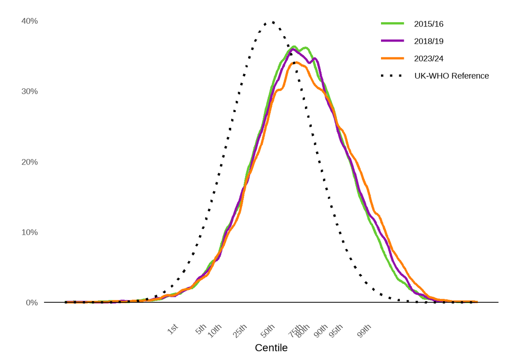

**Figure 53:** Distribution of body mass index of children and young people with Type 1 diabetes in 2015/16, 2018/19 and 2023/24 compared to the 1990 reference population

Figure 54 shows that the percentage of boys and girls with overweight or obesity increases with deprivation, and that girls aged under 12 were less likely to be overweight or obese compared to boys, whereas this trend was reversed in girls and boys aged 12 and above.

[interactive chart not shown]

**Figure 54:** Percentage of children and young people with Type 1 diabetes within the overweight or obese BMI category, by deprivation quintile, age group and sex, 2023/24

Figure 55 shows that higher percentages of children and young people with Type 1 diabetes at a healthy weight are meeting lower HbA1c targets compared to children and young people with overweight or obesity. Underweight children and young people are more likely to have an HbA1c exceeding 80mmol/mol.

[interactive chart not shown]

**Figure 55:** Percentage of children and young people with Type 1 diabetes achieving HbA1c targets by BMI category, 2023/24

Figure 56 breaks down each BMI category for children and young people with Type 1 by treatment regimen/technology usage. It shows that similar proportions of children and young people with Type 1 diabetes with obesity, overweight or healthy weight use each treatment regimen/technology. However, a higher proportion of underweight children with Type 1 diabetes use injections (or injections in combination with Flash/mFlash), while a lower proportion use closed-loop systems or insulin pumps in combination with Flash/mFlash or real time continuous glucose monitors (rtCGMs).

[interactive chart not shown]

**Figure 56:** Percentages of children and young people with Type 1 diabetes in each BMI category with valid treatment regimen and technology records using different combinations of treatment regimens and glucose monitoring, 2023/24

#### 3.6.2.2 Body Mass Index and Type 2 diabetes

Table 27 shows the percentage of children and young people with Type 2 diabetes in each BMI category for England and Wales from 2016/17 to 2023/24. It shows that in each audit year, most children and young people with Type 2 diabetes were obese.

**Table 27:** Body mass index categories for children and young people with Type 2 diabetes, 2016/17 to 2023/24

| Audit Year | Total (n) | Underweight (%) | Healthy weight (%) | Overweight (%) | Obese (%) |
| --- | --- | --- | --- | --- | --- |
| 2016/17 | 658 | 6.5* |  | 8.1 | 85.4 |
| 2017/18 | 677 | 0.0 | 5.9 | 9.5 | 84.6 |
| 2018/19 | 737 | 7.6* |  | 7.7 | 84.7 |
| 2019/20 | 796 | 7.2* |  | 8.7 | 84.2 |
| 2020/21 | 648 | 8.1* |  | 7.4 | 84.6 |
| 2021/22 | 972 | 7.2* |  | 7.3 | 85.5 |
| 2022/23 | 1100 | 6.5* |  | 6.5 | 86.9 |
| 2023/24 | 1201 |  | 6* | 7.3 | 86.7 |

* Results merged to mask small numbers

Figure 57 shows similar percentages of children and young people with Type 2 diabetes within each weight category when broken down by sex.

[interactive chart not shown]

**Figure 57:** Percentage of children and young people with Type 2 diabetes who were in healthy weight, overweight or obese categories by sex, 2023/24

Figure 58 shows the distribution of BMI of children and young people with Type 2 diabetes for 2023/24 compared to the 1990 reference population, along with 2019/20 audit data. It shows that the 2023/24 BMIs of the majority of children and young people with Type 2 diabetes are in the 99th centile of the 1990 reference population, and that this pattern was also seen pre-pandemic in 2019/20.

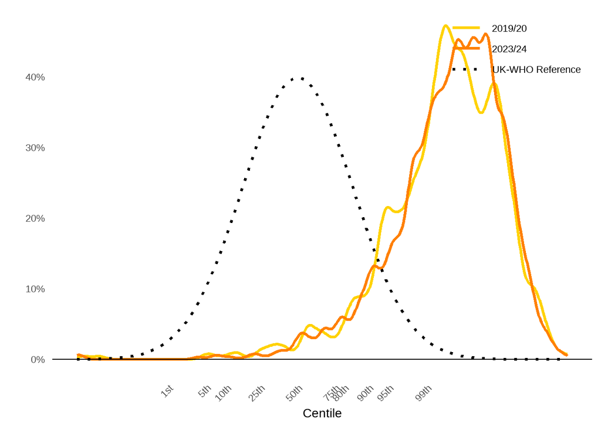

**Figure 58:** Distribution of body mass index of children and young people with Type 2 diabetes in 2019/20 and 2023/24 compared to the 1990 reference population

## 3.7 Psychological assessment

Psychological assessment and access to psychology services should be available to all children and young people and their families with diabetes as children and young people with diabetes have a greater risk of emotional and behavioral difficulties. All children and young people with diabetes and their family members or carers (as appropriate) should be offered emotional support after diagnosis, which should be tailored to their emotional, social, cultural and age-dependent needs.

### 3.7.1 Psychological outcomes of children and young people with Type 1 diabetes

There were 25,244 (76.9%) children and young people with Type 1 diabetes recorded as having a psychological screening assessment within the audit period, 84.5% (n=21,327) of whom had a known outcome of the assessment recorded. Of these, 28.4% (n=6,054) were assessed as requiring additional psychological or CAMHS support outside of multidisciplinary team (MDT) clinics (hereafter ‘additional psychological support’). Table 28 shows a decrease in the number of children and young people recorded as requiring additional support compared to 2022/23.

**Table 28:** Outcome of assessment of the need for psychological support, for children and young people with Type 1 diabetes, 2017/18 – 2023/24

| Audit Year | No. of children and young people with a known outcome of psychological assessment | Required additional support (n) | Required additional support (%) |
| --- | --- | --- | --- |
| 2017/18 | 20114 | 5672 | 28.2 |
| 2018/19 | 20852 | 8153 | 39.1 |
| 2019/20 | 21137 | 9283 | 43.9 |
| 2020/21 | 19434 | 9031 | 46.5 |
| 2021/22 | 21616 | 8425 | 39.0 |
| 2022/23 | 21827 | 6969 | 31.9 |
| 2023/24 | 21327 | 6054 | 28.4 |

Figure 59 shows that the percentages of younger boys and girls assessed as requiring additional psychological support were similar up to age 11. Rates diverged thereafter as more adolescent girls were recorded as requiring additional support compared to adolescent boys.

[interactive chart not shown]

**Figure 59:** Percentage of children and young people with Type 1 diabetes who were assessed as requiring additional psychological support by age and sex, 2023/24

Figure 60 shows that children and young people with Type 1 diabetes who required additional psychological support were more likely to have an HbA1c in the higher target range compared to those who did not require additional psychological support.

[interactive chart not shown]

**Figure 60:** Percentage of children and young people with Type 1 diabetes achieving HbA1c targets by outcome of psychological assessment, 2023/24

### 3.7.2 Psychological outcomes of children and young people with Type 2 diabetes

There were 759 (55.8%) children and young people with Type 2 diabetes recorded as receiving a psychological assessment within the audit period, 614 (80.9%) of whom had a known outcome of the assessment recorded.

Of the children and young people with Type 2 diabetes with a known result, 238 (38.8%) were assessed as requiring additional psychological or CAMHS support outside of MDT clinics (Table 29).

**Table 29:** Outcome of assessment of the need for psychological support and/or child and adolescent mental health services (CAMHS) support, for children and young people with Type 2 diabetes, 2017/18 – 2023/24

| Audit Year | No. of children and young people with a known outcome of psychological assessment | Required additional support (n) | Required additional support (%) |
| --- | --- | --- | --- |
| 2017/18 | 417 | 126 | 30.2 |
| 2018/19 | 457 | 208 | 45.5 |
| 2019/20 | 534 | 286 | 53.6 |
| 2020/21 | 506 | 301 | 59.5 |
| 2021/22 | 636 | 307 | 48.3 |
| 2022/23 | 654 | 271 | 41.4 |
| 2023/24 | 614 | 238 | 38.8 |

## 3.8 Hospital admissions

Diabetes-related hospital admission rates in this section have been calculated from data submitted by PDUs. Previous hospital admission reports from the NPDA have utilised linked admission data taken from [Hospital Episode Statistics (HES)](https://digital.nhs.uk/data-and-information/data-tools-and-services/data-services/hospital-episode-statistics) in England, and the [Patient Episode Database for Wales (PEDW)](https://dhcw.nhs.wales/data/statistical-publications-data-products-and-open-data/archived-pedw-data-online/) ([RCPCH, 2023](https://www.rcpch.ac.uk/sites/default/files/2023-07/npda_report_on_admissions_2015-2020v2.pdf)), hence rates are not directly comparable. NPDA reported admissions data submitted by PDUs for the first time in the 2016/17 core report to encourage submission of higher quality admissions data, which permits regional network and unit level comparisons.

Results in this section are presented for children and young people with Type 1 diabetes only due to small numbers with other types of diabetes. In 2023/24, 164 out of 172 PDUs submitted admission data for children and young people with Type 1 diabetes. There were 5,490 diabetes-related admissions within the 2023/24 audit year reported for 4,383 children and young people with Type 1 diabetes.

### 3.8.1 Type 1 diabetes-related admissions

Table 30 shows the percentages of children and young people with Type 1 diabetes being managed within PDUs who submitted admissions data, and who were admitted at least once with a diabetes-related admission, not associated with diagnosis, within the audit year by country.

**Table 30:** Percentage of children and young people with Type 1 diabetes admitted at least once for a diabetes-related reason that was not associated with diagnosis in England and Wales, 2023/24

| Country | No. of children and young people with T1 diabetes* | Diabetic ketoacidosis | Hypoglycaemia | Ketosis without acidosis | Stabilisation | Other (incl. surgery) |
| --- | --- | --- | --- | --- | --- | --- |
| England and Wales | 31026 | 2.1% | 0.8% | 0.7% | 1.9% | 3.0% |
| England | 29407 | 2.2% | 0.8% | 0.6% | 1.9% | 3.0% |
| Wales | 1619 | 1.9% | 0.3% | 1.0% | 2.3% | 2.3% |

* Totals shown include only children and young people with Type 1 diabetes being managed by PDUs submitting admissions data.

### 3.8.2 DKA at diagnosis

[interactive chart not shown]

**Figure 61:** Percentage of children and young people with Type 1 diabetes who had DKA at diagnosis in England and Wales, 2023/24

# 4 Treatment regimen and diabetes monitoring

The NPDA collects treatment regimen data and data on usage of glucose monitoring technology amongst children and young people with diabetes. Where a treatment regimen and/or glucose monitoring technology changes throughout the audit year, the latest regimen recorded is used for the analysis.

## 4.1 Treatment regimens

### 4.1.1 Treatment regimens of children and young people with Type 1 diabetes

There were 31,624 children and young people with Type 1 diabetes with a valid treatment regimen recorded within the audit period. Table 31 provides a breakdown of the treatment regimens recorded by country for children and young people with Type 1 diabetes.

**Table 31:** Percentage of children and young people with Type 1 diabetes, on each treatment regimen, by country, 2023/24

| Country | Number of children and young people with T1 diabetes | Insulin pump | Four or more injections per day | One - three injections per day/ Other |
| --- | --- | --- | --- | --- |
| England and Wales | 31,624 | 54.8% | 43.2% | 2.0% |
| England | 30,041 | 54.6% | 43.3% | 2.1% |
| Wales | 1,583 | 57.7% | 41.9% | 0.4% |

In England and Wales, 1.4% of children and young people with Type 1 diabetes using insulin injections were also using other blood glucose lowering medication (BGLM), whereas 0.4% of children and young people using insulin pump therapy were using other BGLM.

Figure 62 shows the breakdown of insulin regimens amongst those with a recorded sex and age (n=31,549). Younger children (< 4 years) were more likely to be using insulin pump therapy than older children, in keeping with the trend seen in other European and transatlantic cohorts ([Sherr et al., 2016](https://pubmed.ncbi.nlm.nih.gov/26546085/)), and pump usage was more prevalent in girls.

[interactive chart not shown]

**Figure 62:** Percentage of children and young people with Type 1 diabetes recorded as using insulin injections or insulin pump therapy by age and sex, 2023/24

Since 2014/15, there has been an increase in insulin pump usage for all age groups with a corresponding reduction in use of insulin injections (Figure 63).

[interactive chart not shown]

**Figure 63:** Percentage of children and young people either on daily insulin injections or pump therapy by age group, 2014/15 to 2023/24

Insulin pump usage increased with duration of diabetes (Figure 64) with 66.0% of those in their first year of diagnosis of Type 1 diabetes using insulin injections, compared to 31.9% of those with 15 years or more since diagnosis. The percentage of those using insulin pumps in the first year of Type 1 diabetes increased, from 24.8% in 2022/23 to 34.0% in 2023/24.

[interactive chart not shown]

**Figure 64:** Percentage of children and young people either on daily insulin injections or pump therapy by duration of diabetes for England and Wales, 2023/24

Figure 65 shows that White children and young people were more likely to be using a pump compared to those within other ethnic groups. Insulin pump therapy usage was also more prevalent in those living in the least deprived areas compared to the most deprived areas of the country. Increases in insulin pump therapy usage was seen across every ethnicity and deprivation quintile, compared to the previous audit years.

[interactive chart not shown]

**Figure 65:** Percentage of children and young people with Type 1 diabetes using insulin pump therapy by ethnic group and deprivation, 2019/20 to 2023/24

Figure 66 shows a narrowing of the gap in insulin pump usage between children and young people from the most and least deprived areas. In 2018/19, the proportions using insulin pump therapy were 29.6% in the most deprived areas and 43% in the least deprived areas (a difference of 13.4%). By 2023/24, these figures were 50% and 59.5%, respectively, reducing the gap to 9.5%. Overall, there has been a reduction of the gap between the 2022/23 (11.9%) and 2023/24 (9.5%) audit years.

[interactive chart not shown]

**Figure 66:** Percentage of children and young people with Type 1 diabetes using insulin injections or insulin pump therapy by “least” and “most” deprived quintile, 2014/15 to 2023/24

Figure 67 shows a general trend for children and young people with Type 1 diabetes using insulin pump therapy achieving lower HbA1c targets compared to those on insulin injections. These data do not account for the influence of deprivation, age, duration of diabetes or other factors (such as the use of CGM) which may influence the choice of insulin regimen, and impact upon target achievement.

[interactive chart not shown]

**Figure 67:** Percentage of children and young people with Type 1 diabetes achieving HbA1c targets by insulin treatment regimen, 2023/24

### 4.1.2 Treatment regimens of children and young people with Type 2 diabetes

Table 32 shows the breakdown of diabetes treatment regimen for children and young people with Type 2 diabetes. Treatment regimen was either missing or reported as ‘unknown’ for 22.9% of children and young people with Type 2 diabetes.

**Table 32:** Percentage of children and young people with Type 2 diabetes using each treatment regimen, England and Wales, 2021/22 to 2023/24

| Measure | 2021/22 | 2022/23 | 2023/24 |
| --- | --- | --- | --- |
| No. of children and young people with Type 2 diabetes with a recorded treatment regimen (n) | 855 | 954 | 1048 |
| 1-3 insulin injections/day (%) | 4.1 | 5.1 | 3.4 |
| 1-3 insulin injections/day and other BGLM (%)* | 11.2 | 12.6 | 13.1 |
| 4 or more insulin injections/day (%) | 11.1 | 10.5 | 9.0 |
| 4 or more insulin injections/day and other BGLM (%)* | 10.6 | 11.4 | 11.0 |
| Insulin pump (%) | 1.6† | 1.3† | 1.3† |
| Insulin pump and other BGLM (%)* |  |  |  |
| Dietary management (%) | 11.9 | 12.3 | 11.4 |
| Dietary management and other BGLM (%)* | 49.4 | 46.9 | 50.9 |

† Results merged to mask small numbers * And other blood glucose lowering medication

## 4.2 Glucose monitoring devices

NICE guidance applicable at the time of the 2020/21 audit ([NG18](https://www.nice.org.uk/guidance/ng18)) stated that ongoing real time continuous glucose monitoring (rtCGM) monitoring with alarms to children and young people with Type 1 diabetes who:

- had frequent severe hypoglycaemia or
- had impaired hypoglycaemia awareness that is associated with adverse consequences (for example, seizures or anxiety) or
- couldn’t recognise or communicate about symptoms of hypoglycaemia (for example, because of cognitive or neurological disabilities).

However, newer guidance published in 2022 ([NG18- 2022](https://www.nice.org.uk/guidance/ng18/resources/2022-exceptional-surveillance-of-diabetes-type-1-and-type-2-in-children-and-young-people-diagnosis-and-management-nice-guideline-ng18-pdf-14123084682949)) now recommends that it should be offered to all children and young people with Type 1 diabetes, as long as it is provided alongside education to support children and young people and their families and carers to use it.

### 4.2.1 Usage of glucose monitoring devices among children and young people with Type 1 diabetes

There were 30,785 children and young people with Type 1 diabetes with a valid indication of glucose monitoring usage (indicating use of a specific technology or none) reported within the audit period. Figure 68 presents this number broken down by country.

rtCGMs were the most used glucose monitoring device in England and Wales (78.7%), followed by Flash glucose monitors (13.3%). Additionally, 1.5% of children and young people with Type 1 diabetes in both countries used modified Flash glucose monitors (mFlash), whereas 6.5% did not use Flash/mFlash or rtCGM. There has been a substantial increase in those using rtCGMs overall since the previous audit year of 2022/23 (an increase from 48.6% to 78.7%). These results should be interpreted with some caution given that 6.2% (n = 2,024) of children and young people with Type 1 diabetes had an unknown or missing entry for this data item.

In this section, those using rtCGM as part of a closed loop system are included in the rtCGM numerators. Usage of closed loop systems as a treatment regimen is presented in section 4.3.

[interactive chart not shown]

**Figure 68:** Percentage breakdowns of stated glucose monitoring device usage in England and Wales, 2023/24

Figure 69 shows that younger children with Type 1 diabetes were more likely to be using rtCGM, and less likely to use Flash or mFlash devices, than those who were older.

[interactive chart not shown]

**Figure 69:** Percentages of children and young people with Type 1 diabetes by glucose monitoring device usage, by age and sex, 2023/24

Figure 70 shows that children and young people living with Type 1 diabetes for ten years or more are less likely to be using an rtCGM and more likely to be using Flash/mFlash monitors.

[interactive chart not shown]

**Figure 70:** Percentage of children and young people with Type 1 diabetes with glucose monitoring device usage, by duration of diabetes, 2023/24.

Figure 71 shows how use of glucose monitoring devices differs by ethnic group and deprivation quintile.

A large increase in the proportion using rtCGMs can be seen in all ethnic groups and deprivation quintiles (see black line which represents 2022/23 rtCGM use). Black children and young people with Type 1 diabetes had the lowest usage of rtCGMs, while also having the highest proportion using Flash or mFlash devices and the highest proportion stating no usage of other glucose monitoring devices. Mixed and White children and young people had the highest usage of rtCGMs.

Figure 71 also shows a strong association between deprivation and rtCGM use, with children and young people with Type 1 diabetes living in more deprived areas being less likely to use rtCGMs than those living in less deprived areas. Children and young people living in the most deprived areas were also most likely to use no other glucose monitoring device.

[interactive chart not shown]

**Figure 71:** Percentage of children and young people with Type 1 diabetes with stated glucose monitoring device usage, by ethnic group and deprivation quintile 2023/24 (with comparison of rtCGM 2022/23).

Figure 72 shows the usage of rtCGMs within each ethnic group by deprivation quintile. It shows that rtCGM use was more prevalent among those living in the least and second least deprived quintile within most ethnic groups, and that Black children and young people typically had lower use than other ethnic groups in most deprivation quintiles.

[interactive chart not shown]

**Figure 72:** Percentage of children and young people with Type 1 diabetes using an rtCGM by ethnic group and deprivation quintile, 2023/24

Figure 74 shows that the gap between those living in the most and least deprived areas has narrowed in the last years, from 13.8% in 2021/22 to 6.9% in 2023/24.

[interactive chart not shown]

**Figure 74:** Percentage of children and young people with Type 1 diabetes using a rtCGM by “least” and “most” deprived quintile, 2017/18 to 2023/24

Figure 75 shows that children and young people with Type 1 diabetes using rtCGM were more likely to achieve lower HbA1c targets compared to those who were not using rtCGM.

[interactive chart not shown]

**Figure 75:** Percentage of children and young people with Type 1 diabetes achieving HbA1c targets by rtCGM usage, 2023/24

Figure 76 shows that rtCGM was more prevalent amongst pump users than those using insulin injections. Conversely, Flash or mFlash monitors were more likely to be used by those on insulin injections than amongst pump users. Children and young people with Type 1 diabetes using insulin injections were also more likely to not be using any glucose monitoring device.

[interactive chart not shown]

**Figure 76:** Percentage of children and young people with Type 1 diabetes using insulin injections or insulin pump therapy by glucose monitoring device usage, 2023/24

Figure 77 shows that the usage of rtCGMs has increased in each audit year since 2018/19. The 2023/24 audit year is the third in which data on HCL systems were collected. Usage of HCL systems has increased in England and Wales and now accounts for 38.2% (16.6% in 2022/23) of children and young people with Type 1 diabetes with a valid record of treatment regimen and technology usage.

[interactive chart not shown]

**Figure 77:** Percentages of children and young people with Type 1 diabetes with valid treatment regimen and technology usage records using different combinations of treatment regimens and glucose monitoring, by country, 2018/19 to 2023/24

Figure 78 shows the proportions of children and young people with Type 1 diabetes using different combinations of treatment regimens and glucose monitoring devices achieving HbA1c targets.

Those using HCL systems were the most likely to achieve the lowest HbA1c targets, followed by those using rtCGMs in combination with injections or pump therapy. Those using insulin pumps or injections without glucose monitoring devices, or with insulin pumps in combination with Flash monitors, were the least likely to achieve lower HbA1c targets.

[interactive chart not shown]

**Figure 78:** Percentage of children and young people with Type 1 diabetes achieving HbA1c targets by treatment regimen in combination with glucose monitoring devices (where applicable), 2023/24

## 4.3 Hybrid Closed Loop (HCL) systems

NICE guidance published in 2022 ([NICE NG18 updated](https://www.nice.org.uk/guidance/ng18/resources/2022-exceptional-surveillance-of-diabetes-type-1-and-type-2-in-children-and-young-people-diagnosis-and-management-nice-guideline-ng18-pdf-14123084682949)) states that when choosing a continuous glucose monitoring device, the compatibility of a child or young person’s insulin regimen or type of insulin pump with a hybrid closed loop should be considered. This update was followed by publication of a technology appraisal by NICE in December 2023 recommending HCL systems as an option for managing blood glucose levels in type 1 diabetes for children and young people ([NICE TA943, 2023](https://www.nice.org.uk/guidance/ta943)).

### 4.3.1 Usage of HCL systems among children and young people with Type 1 diabetes

There were 11,698 children and young people with Type 1 diabetes recorded as using HCL in England and Wales in the 2023/24 audit year. This accounts for 35.7% of all children and young people with Type 1 diabetes, higher than the proportion reported in the 2022/23 audit (14.7%).

Table 33 shows the breakdown of HCLs by licensing status in the UK.

**Table 33:** Breakdown of closed loop licensing status for children and young people with Type 1 diabetes in England and Wales, 2023/24

| Country | Total with T1D (n) | Licenced (%) | Unknown licenced status (%) | DIY unlicenced (%) | Any type (%) |
| --- | --- | --- | --- | --- | --- |
| England & Wales | 32,809 | 33.9 | 0.3 | 1.4 | 35.7 |
| England | 31,190 | 34.1 | 0.2 | 1.4 | 35.7 |
| Wales | 1,619 | 31.4 | 2.2 | 1.2 | 34.7 |

Figure 79 shows that the distribution of HCL usage is not uniform throughout England and Wales, with usage by PDU ranging from 0.5% to 89.9% of children and young people with Type 1 diabetes.

[interactive chart not shown]

**Figure 79:** Column chart of HCL usage by children and young people with Type 1 diabetes in England and Wales per PDU, 2023/24

Figure 80 shows the usage of HCLs by age and sex. Higher proportions of those in the younger age groups (0-4 and 5-9 years) were using HCLs than those in older age groups (10-14 and 15-19 years). There was little variation between sexes.

[interactive chart not shown]

**Figure 80:** Percentage of children and young people with Type 1 diabetes recorded as using HCLs by age and sex, 2023/24

Figure 81 shows the usage of HCL by ethnicity (left) and deprivation quintile (right) for the 2022/23 and 2023/24 audit years. In 2023/24, White children and young people with Type 1 diabetes had the highest usage of HCLs (37.4%), while those of Black ethnicity had the lowest recorded usage (25.4%).

There was a clear pattern associating less deprivation with increased HCL usage again in 2023/24, with 32.5% of those living in the most deprived areas using HCLs compared to 39% of those in the least deprived areas.

[interactive chart not shown]

**Figure 81:** Percentage of children and young people with Type 1 diabetes using closed loop systems, by ethnic group and deprivation quintile, 2022/23 - 2023/24

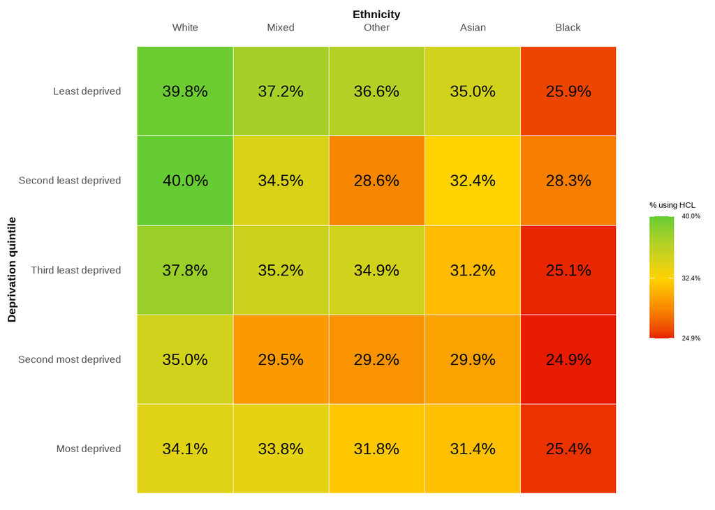

**Figure 82:** Percentage of children and young people with Type 1 diabetes using HCLs by ethnic group and deprivation quintile, 2023/24

# 5 Thyroid and coeliac disease

## 5.1 Thyroid and coeliac disease amongst children and young people with Type 1 diabetes

Children and young people with Type 1 diabetes are at an increased risk of other autoimmune conditions including thyroid (both hypo- and hyperthyroidism) and coeliac disease.

Table 34 shows that the prevalence of thyroid disease in 2023/24 for children and young people with Type 1 diabetes was 2.6%, similar to that reported in 2022/23 (2.8%). 5.7% of children and young people with Type 1 diabetes had coeliac disease, compared to 5.7% in 2022/23. This figure is also higher than the prevalence rate of 3.5% reported in an international collaborative study across three continents (Craig et al., 2017).

There were 93 (0.3%) children and young people with Type 1 diabetes who had both coeliac disease and thyroid disease in England and Wales.

**Table 34:** Percentage of children and young people with Type 1 diabetes with thyroid or coeliac disease by country, 2023/24

| Country | Coeliac | Thyroid | No of CYP with T1 diabetes |
| --- | --- | --- | --- |
| England and Wales | 5.7% | 2.6% | 32809 |
| England | 5.7% | 2.7% | 31190 |
| Wales | 5.4% | 1.2% | 1619 |

Figure 83 shows year-on-year variation in prevalence of thyroid and coeliac disease amongst those with Type 1 diabetes.

[interactive chart not shown]

**Figure 83:** Percentage of children and young people with Type 1 diabetes with thyroid or coeliac disease in England and Wales, 2014/15 to 2023/24.

Figure 84 shows that there has been a consistent higher prevalence of both autoimmune conditions amongst girls compared to boys since the 2017/18 audit.

[interactive chart not shown]

**Figure 84:** Percentage of children and young people with Type 1 diabetes and comorbid coeliac or thyroid disease by sex, 2017/18 to 2023/24

Coeliac disease prevalence was higher amongst children and young people with Type 1 diabetes living in the least deprived areas compared to the most deprived areas but there was no clear association between prevalence of thyroid disease and areas of deprivation (Figure 85).

[interactive chart not shown]

**Figure 85:** Percentage of children and young people with Type 1 diabetes and coeliac or thyroid disease by deprivation quintile, 2023/24

Figure 86 shows that the prevalence of both autoimmune conditions was highest amongst Asian and White children and young people with Type 1 diabetes. Those of Black ethnicity had the lowest rates of both coeliac and thyroid disease out of all ethnic groups.

[interactive chart not shown]

**Figure 86:** Percentage of children and young with Type 1 diabetes and coeliac or thyroid disease by ethnic group, 2023/24

Figure 87 shows that there is little difference in HbA1c target achievement between those children and young people with Type 1 diabetes who have coeliac disease, those who have thyroid disease and those who have neither.

[interactive chart not shown]

**Figure 87:** Percentage of children and young people with Type 1 diabetes achieving HbA1c targets by autoimmune disease status, 2023/24

# 6 List of Tables

- Table 1: Number of children and young people with diabetes by age-group and type of diabetes in 2023/24

# 7 List of Figures

## Footnotes

[^1]: NHS Digital (2024): [National Diabetes Audit: Adolescents and Young Adults with Type 1 Diabetes 2017–23](https://digital.nhs.uk/data-and-information/publications/statistical/national-diabetes-audit-aya/nda-aya-2017-23)
[^2]: Data obtained from the [UK Census](https://census.gov.uk/)
[^3]: Prevalence in this report refers to the proportion of children and young people in England and Wales who have Type 1 diabetes, based on NPDA data and the total population for the relevant age group. Population estimates for England and Wales were obtained from the [Office for National Statistics](https://www.ons.gov.uk/peoplepopulationandcommunity/populationandmigration/populationestimates/datasets/populationestimatesforukenglandandwalesscotlandandnorthernireland).
[^4]: Incidence in this report refers to the number of children and young people in England and Wales who are newly diagnosed with Type 1 diabetes during the audit year, based on NPDA data and the total population for the relevant group. Population estimates for England and Wales were obtained from the [Office for National Statistics](https://www.ons.gov.uk/peoplepopulationandcommunity/populationandmigration/populationestimates/datasets/populationestimatesforukenglandandwalesscotlandandnorthernireland).
[^5]: RCPCH (2025): [National Paediatric Diabetes Audit: Type 2 Diabetes Spotlight Audit 2023/24](https://www.rcpch.ac.uk/sites/default/files/2025-04/ref532_npda_type_2_spotlight_report_2023-24_state_of_the_nation_report_r2.pdf)
[^6]: NHS Digital (2024): [National Diabetes Audit: Young People with Type 2 Diabetes, 2022–23](https://digital.nhs.uk/data-and-information/publications/statistical/national-diabetes-audit-yt2)
[^7]: Data obtained from the [UK Census](https://census.gov.uk/)